# Puppy Source Analysis - New Sources

## Q37

**Q37: How likely are you to recommend the place where you got your puppy to a friend?**

3880 non-empty/NA responses out of 4002 possible responses ( 97 %)

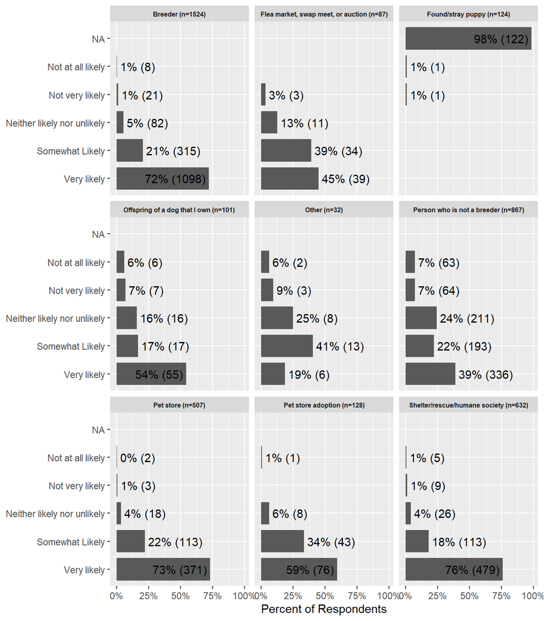

## Q38

**Q38: If you had not been able to get your puppy, what would you have most likely done?**

3764 non-empty/NA responses out of 4002 possible responses ( 94 %)

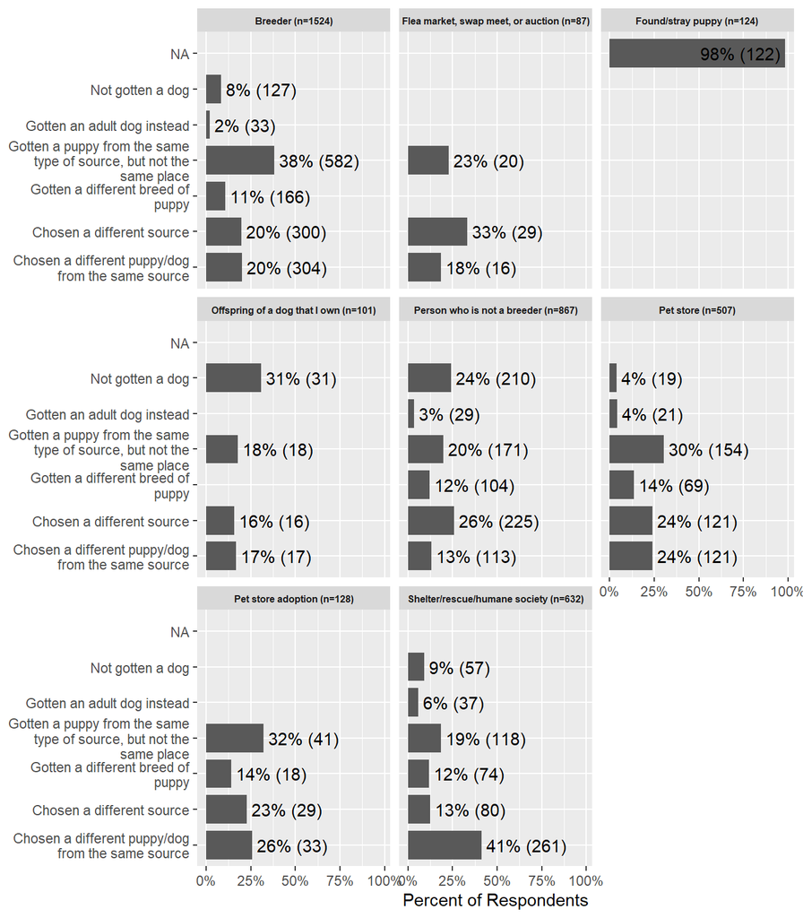

## Q90

**Q90: When you got your puppy, was there a policy for if you can no longer keep them?**

3708 non-empty/NA responses out of 3708 possible responses ( 100 %)

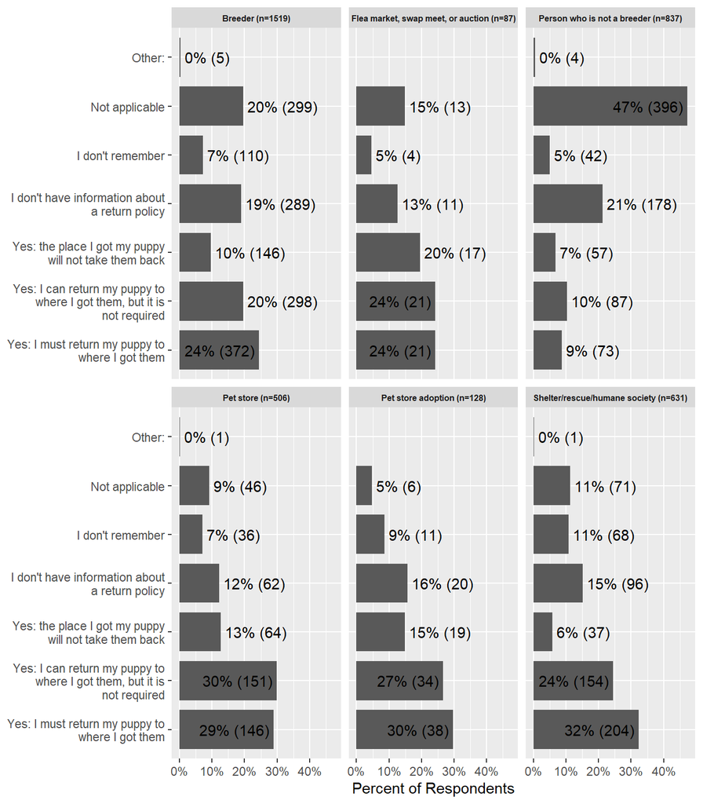

## Q92

**Q92: Did your puppy come with a health guarantee?**

3708 non-empty/NA responses out of 3708 possible responses ( 100 %)

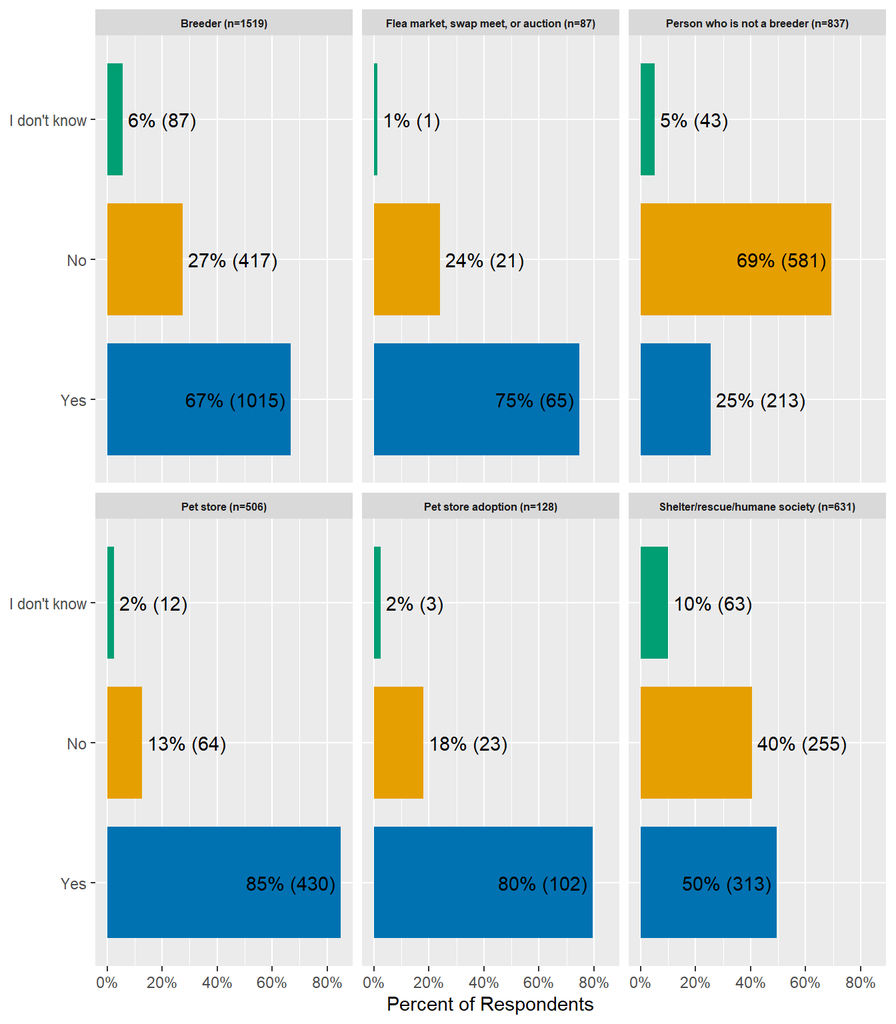

## Group B Only (…)

**Group B Only**

### > Q94

**Q94: Overall, how satisfied are you with your new puppy?**

2001 non-empty/NA responses out of 2001 possible responses ( 100 %)

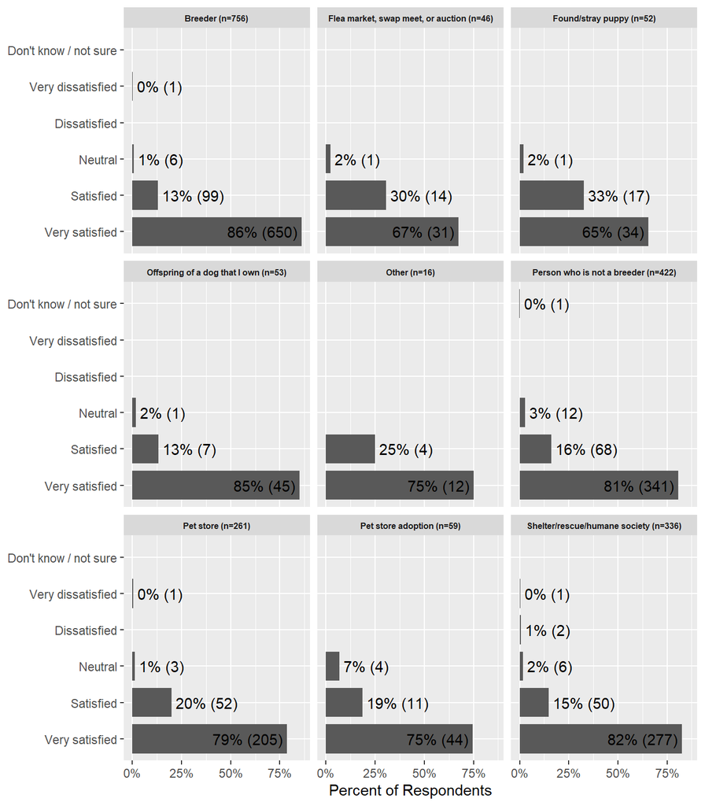

### > Q95

**Q95: How would you describe your puppy’s overall health?**

2001 non-empty/NA responses out of 2001 possible responses ( 100 %)

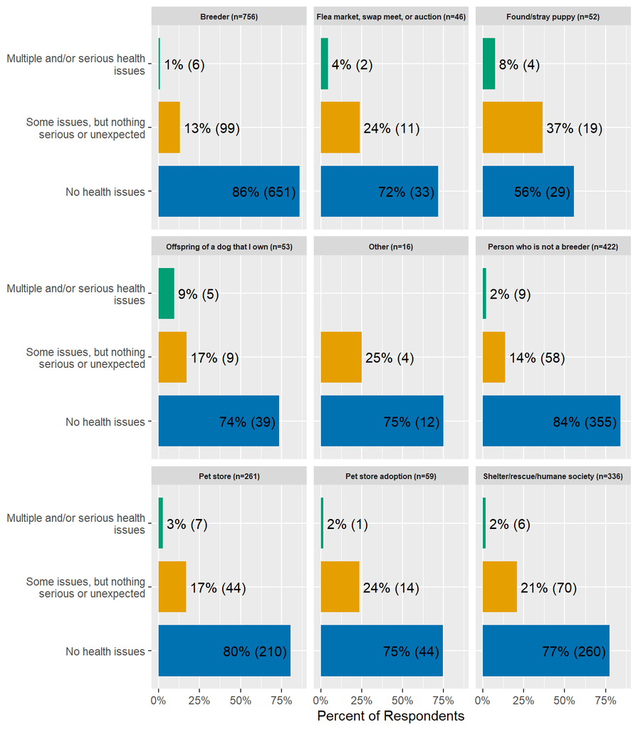

### > Q97

**Q97: How would you describe your puppy’s overall behavior?**

2001 non-empty/NA responses out of 2001 possible responses ( 100 %)

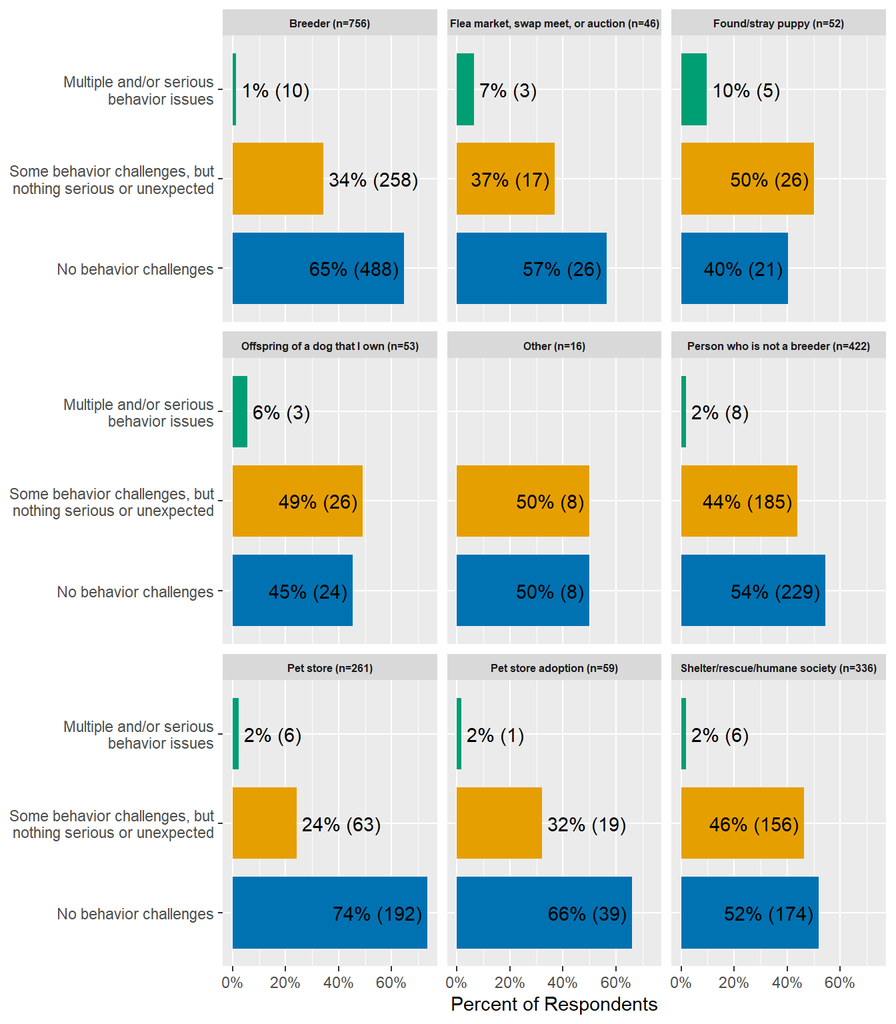

### > Q99

**Have you had challenges or concerns about any of the following?**

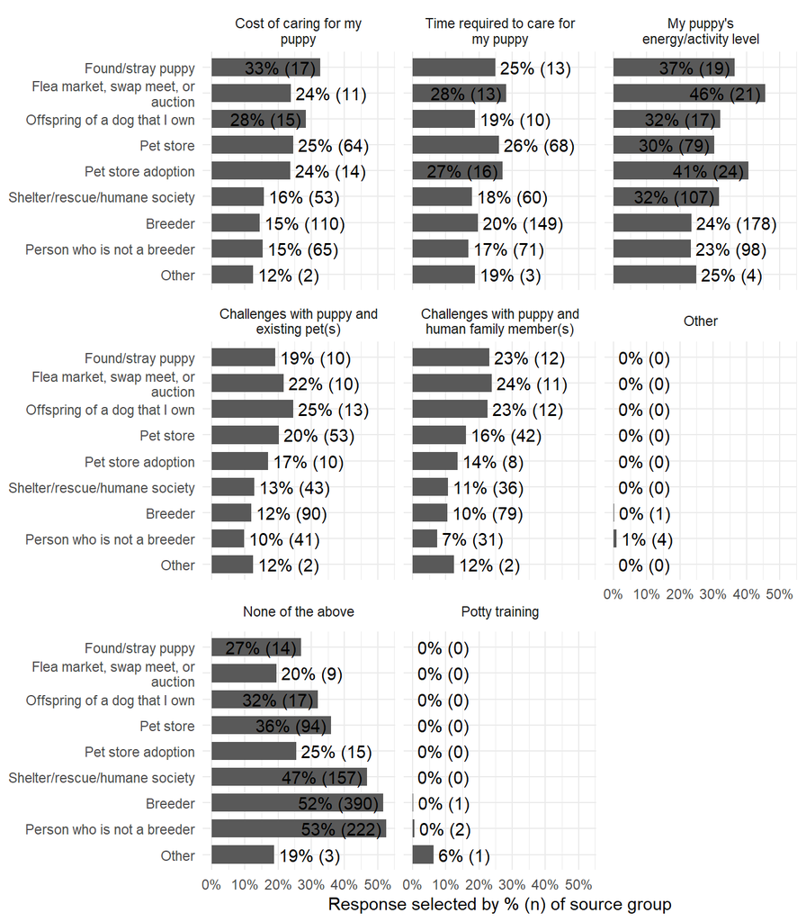

### > Q100 (…)

**Q100: Have you ever considered finding your dog a different home, for any reason? (This does not mean that you did so, just that you considered it.)**

2001 non-empty/NA responses out of 2001 possible responses ( 100 %)

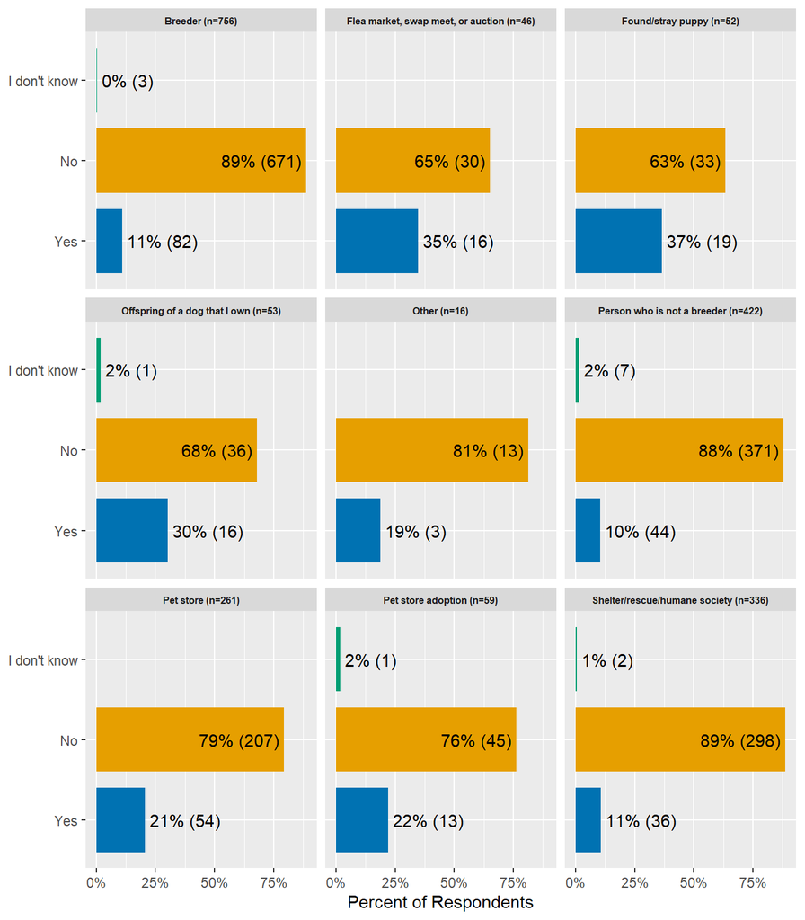

#### >> Q101

**Which of the following are or were causing to you consider rehoming your dog?**

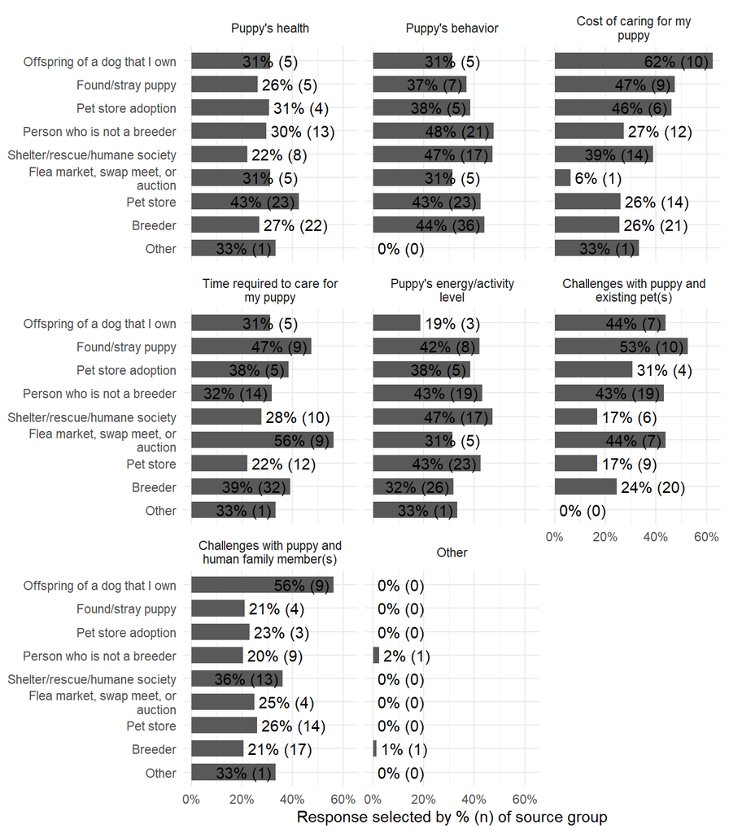

## Q102a

**Q102a: Which state do you live in?**

4002 non-empty/NA responses out of 4002 possible responses ( 100 %)

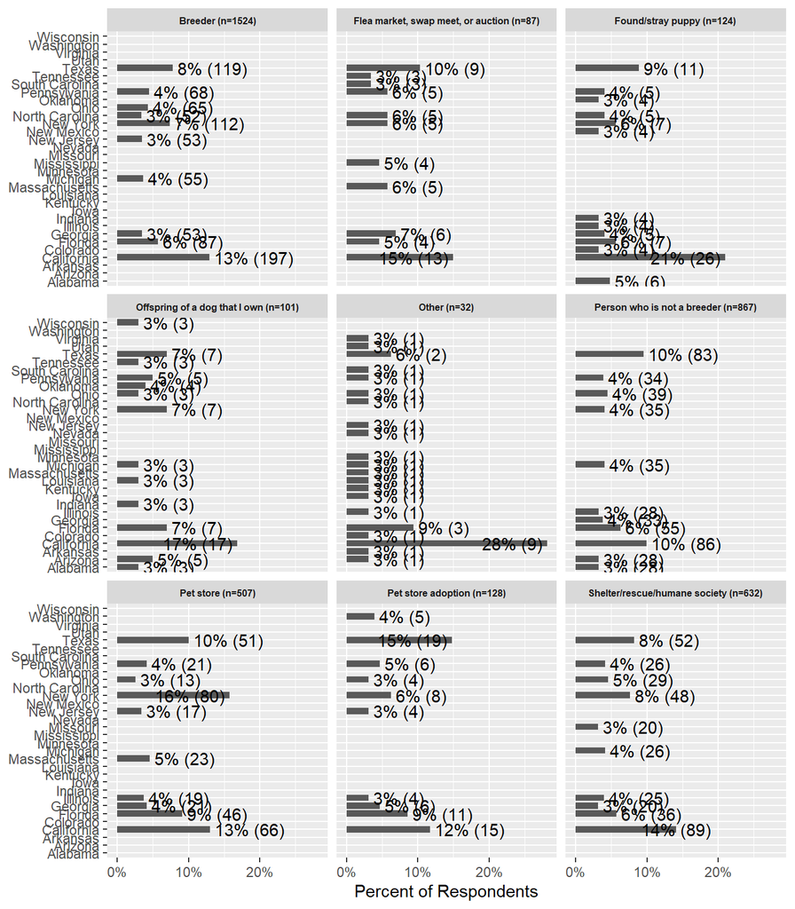

## Q103

**Q103: What is your gender?**

4002 non-empty/NA responses out of 4002 possible responses ( 100 %)

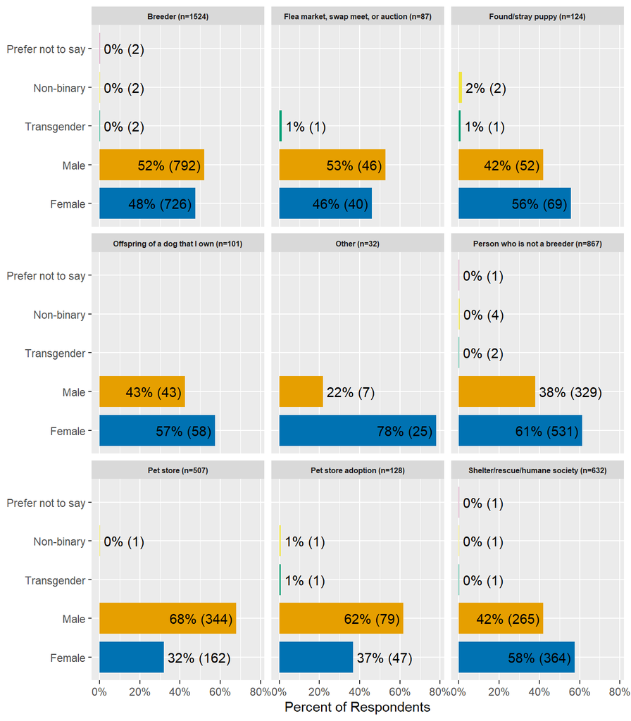

## Q104

**Q104: What is the highest level of school you completed?**

4002 non-empty/NA responses out of 4002 possible responses ( 100 %)

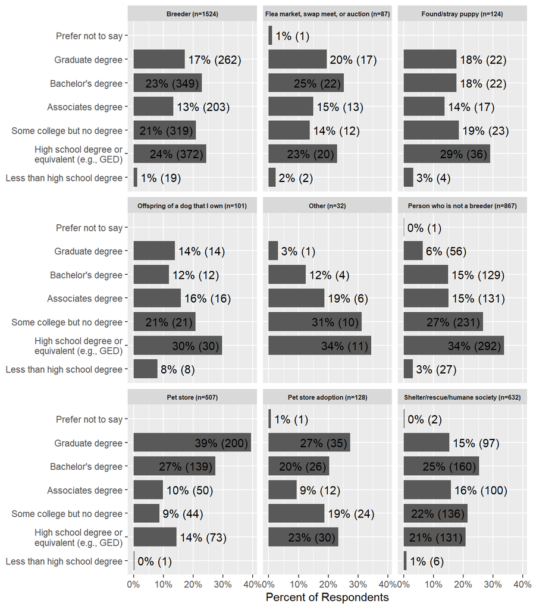

## Q105

**Q105: What is your total annual household income?**

4002 non-empty/NA responses out of 4002 possible responses ( 100 %)

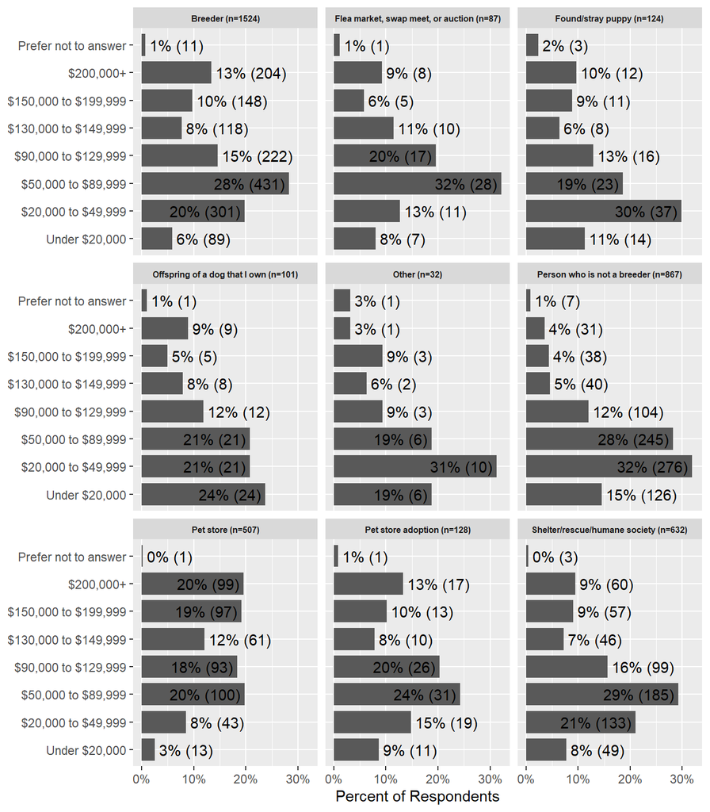

## Q106

**Q106: Are you of Hispanic, Latino, or Spanish origin?**

4002 non-empty/NA responses out of 4002 possible responses ( 100 %)

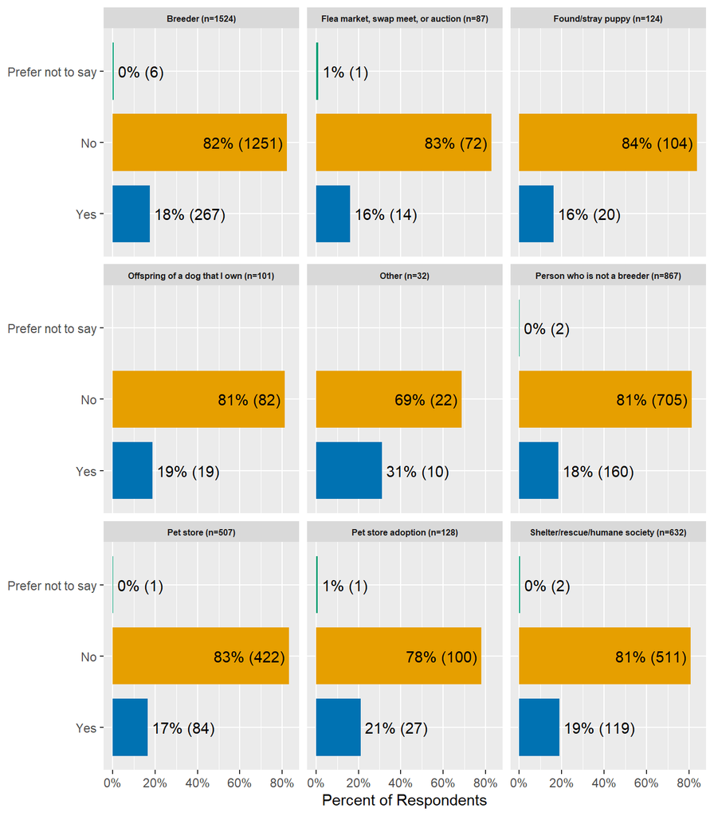

## Q107

**Q107: How would you describe yourself?**

4002 non-empty/NA responses out of 4002 possible responses ( 100 %)

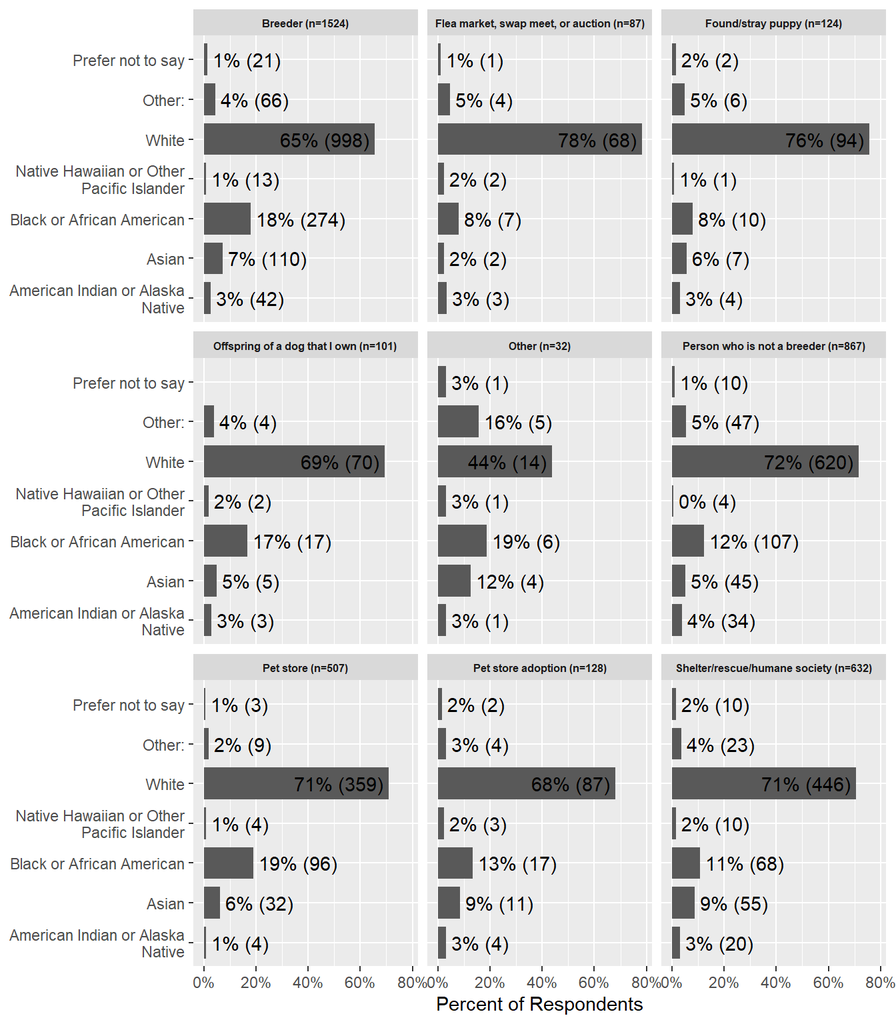

## Q108

**Q108: Do you own or rent your home?**

4002 non-empty/NA responses out of 4002 possible responses ( 100 %)

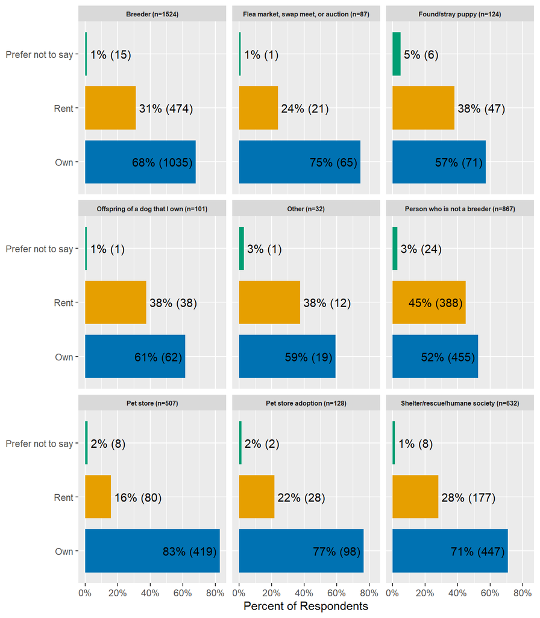